## Udacity Nanodegree Data Analyst

# Project: Investigate a Dataset

- 1. Ask a Question
- 2. Data Wrangling
- 3. Exploratory Data Analysis
- 4. Conclusions

## 1. Ask a Question

- How are trends like the HDI(Human Development Index) and inequality index are affecting suicide and murder rates?
- Are there differences between industrialized countries and poor countries?
- Can we see correlations or unusual trends in the gathered data?

For better observation we will gather data from the gapminder.org dataset.

To get better insights and interesting trends I will group different countries to categories. There will be 3 categories of countries.

- **industrialized countries (IC´s)**
- **newly industrialized countries(NIC´s)**
- **least industrialized countries(LDC´s)**

Those 3 country categories will show up different trends and hopefully give us a clear observation view. Find explanation below.

For this countries we will watch the trends in different key indicators, as we described above. (Please see explanation for those indicators below.)

- **human development index (HDI)**
- **Inequality (GINI)**

Then make observations on how they affect death reasons:

- **suicide deaths**
- **murder deaths**

NOTE: thoughts about investigate the GDP per capita were a basic concept of this notebook, but gdp per capita get coverd within the HDI, because the HDI have a computation factor on the gdp per capita

### 1.1 Explanation

#### Index

###### Gini(inequality):

Gini measures inequality: How large are the income differences within a society. First imagine you line up all people in a country, ordered by income: The poorest to the left and the richest to the right. Now you walk from the left to the right asking how much money they earn every year, and you add up the number. When you reach the middle, you have counted 50% of the people, but the richest half remains. The amount of income you have added up is much less than 50% of all the money, say , maybe 20%. Maybe 10%? If there are lots of people with low incomes, you will have added maybe 15% of the money for the poorest half of the population, but if the income differences are less extreme, the 50% poorest may earn 30% of the incomes. If everybody earns the same, you would have gotten to 50% of the money, after asking 50% of the people. In that case (which never happens), the gini is zero. No inequality. The opposite extreme case (which also never happens) would be that only the richest person has any income: one guy earns all the money. Then the gini is 1. Perfect inequality. But most countries have a gini somewhere around 0.4, in-between these two extreme examples.

https://www.gapminder.org/data/documentation/gini/

##### HDI (Human Development Index)

The HDI was created to emphasize that people and their capabilities should be the ultimate criteria for assessing the development of a country, not economic growth alone. The HDI can also be used to question national policy choices, asking how two countries with the same level of GNI per capita can end up with different human development outcomes. These contrasts can stimulate debate about government policy priorities. The Human Development Index (HDI) is a summary measure of average achievement in key dimensions of human development: a long and healthy life, being knowledgeable and have a decent standard of living. The HDI is the geometric mean of normalized indices for each of the three dimensions.

The health dimension is assessed by life expectancy at birth, the education dimension is measured by mean of years of schooling for adults aged 25 years and more and expected years of schooling for children of school entering age. The standard of living dimension is measured by gross national income per capita. The HDI uses the logarithm of income, to reflect the diminishing importance of income with increasing GNI. The scores for the three HDI dimension indices are then aggregated into a composite index using geometric mean. Refer to Technical notes for more details.

The HDI simplifies and captures only part of what human development entails. It does not reflect on inequalities, poverty, human security, empowerment, etc. The HDRO offers the other composite indices as broader proxy on some of the key issues of human development, inequality, gender disparity and poverty.

A fuller picture of a country's level of human development requires analysis of other indicators and information presented in the statistical annex of the report.

http://hdr.undp.org/en/content/human-development-index-hdi

#### Country types

##### IC:

A developed country, industrialized country (or post-industrial country), more developed country, or more economically developed country (MEDC), is a sovereign state that has a developed economy and advanced technological infrastructure relative to other less industrialized nations. Most commonly, the criteria for evaluating the degree of economic development are gross domestic product (GDP), gross national product (GNP), the per capita income, level of industrialization, amount of widespread infrastructure and general standard of living. Which criteria are to be used and which countries can be classified as being developed are subjects of debate.

https://en.wikipedia.org/wiki/Developed_country

##### NIC :

A newly industrialized country (or NIC) is a developing economy that has transitioned from being based on agriculture or extraction of raw materials, to being primarily based on the production of manufactured goods. These nations have taken important steps towards industrialization and might be considered as developed economies at some point in the near future. Sometimes, these economies are also referred to as emerging markets.

This categorization was first adopted in the second half of the 20th century, originally referring to Hong Kong, Taiwan, South Korea, and Singapore: four economies that were rapidly transforming and moving towards development thanks to high-tech manufacturing. Today, they are considered to have fully developed and are studied as the first generation of NICs.

There is not a total consensus on which nations are NICs, but most economists agree that there are nine at this point in time:

```
China
India
Thailand
Malaysia
Philippines
Turkey
South Africa
Brazil
Mexico
```

China and India represent particularly notable cases. Both nations are industrial giants, and their production surpasses many industrialized nations, but because of their large population, the average income and the overall social development remain low.

https://study.com/academy/lesson/newly-industrialized-countries-characteristics-sectors-of-production.html

##### LDC:

Least developed countries (LDCs) are low-income countries confronting severe structural impediments to sustainable development. They are highly vulnerable to economic and environmental shocks and have low levels of human assets.

There are currently 47 countries on the list of LDCs which is reviewed every three years by the Committee for Development (CDP).

LDCs have exclusive access to certain international support measures in particular in the areas of development assistance and trade. Afghanistan

Angola, Bangladesh, Benin, Bhutan, Burkina Faso, Burundi, Cambodia Central African Republic, Chad, Comoros,Democratic, Republic of the Congo, Djiboutim Eritrea, Ethiopia,Gambia, Guine, Guinea-Bissau, Haiti, Kiribati, Lao People’s Dem. Republic, Lesotho, Liberia, Madagascar, Malawi, Mali, Mauritania, Mozambique, Myanmar, Nepal, Niger,Rwanda,Sao Tome and Principe, Senegal, Sierra Leone, Solomon Islands, Somalia, South Sudan, Sudan, Timor-Leste, Togo, Tuvalu, Uganda, United Republic of Tanzania, Vanuatu,Yemen, Zambia

https://www.un.org/development/desa/dpad/least-developed-country-category.html

### 1.2 Country types

- **Industrialized countries** (IC´s) : Germany, France, United Kingdom (mainly Lands from europe)
- **Newly industrialized countries**(NIC´s): China, Turkey, Mexico (from different continents)
- **Least developed countries** (LDC´s): Bangladesh, Mali, Haiti (from different continents)

  For investigation NIC and LDC get grouped wiht countries from different places to analyze if the key indicators have same effects on different continents, or not.

### 1.3 Color coding system

We will explore and analysis different categories with 3 types of countries, each. For plotting everything in clear plots we need a good color coding system. This will provide better understanding, faster observation and clear communication, and is needed for every complex system to get simplified.

IC´s : **Green color shades for industry countries**

NIC´s : **Blue color shades for industry countries**

LDC´s : **redorange color shades for industry countries**

```python
# colors for ic,nic,ldc

c_germany = 'lime'
c_france = 'green'
c_unitedkingdom = 'greenyellow'

c_china = 'skyblue'
c_turkey = 'royalblue'
c_mexico = 'deepskyblue'

c_bangladesh = 'red'
c_mali = 'darkorange'
c_haiti = 'coral'

# making color palette for plots
c_palette = [c_germany,
c_france,
c_unitedkingdom,
c_china ,
c_turkey,
c_mexico,
c_bangladesh,
c_mali,
c_haiti ]
```

## 2. Wrangle Data

### 2.1 Gather the data

The following datasets are downloaded from the Gapminder.org website.

https://www.gapminder.org/data/

```python
import pandas as pd
import seaborn as sns
import matplotlib.pyplot as plt
import numpy as np
import os as os
%matplotlib inline

# !!!key indictators

df_gdp  = pd.read_csv('C:/Users/name1/data_2_introduction/gdp_total_yearly_growth.csv',index_col=0)
df_hdi = pd.read_csv('C:/Users/name1/data_2_introduction/hdi_human_development_index.csv',index_col=0)
df_gini = pd.read_csv('C:/Users/name1/data_2_introduction/gini.csv',index_col=0)



# !!! inestigation if those data change because of the key indicators


df_mprop = pd.read_csv('C:/Users/name1/data_2_introduction/murder_per_100000_people.csv',index_col=0)

# murder rate total
df_mtotal = pd.read_csv('C:/Users/name1/data_2_introduction/murder_total_deaths.csv',index_col=0)

#suicide rate total
df_stotal = pd.read_csv('C:/Users/name1/data_2_introduction/suicide_total_deaths.csv',index_col=0)


# traffic deaths total
df_ttotal = pd.read_csv('C:/Users/name1/data_2_introduction/traffic_total_deaths.csv',index_col=0)
```

## 2.2 Combine sets

For answering the main questions. The dataframes have to filtered:

- industrializied countries
- newly industrialized countries
- least developed countries

```python
# !!! gathered data frames get filtered for ic,nic,ldc

#gdp
gdp_all = df_gdp.loc[['Germany','United Kingdom','France','China','Mexico','Turkey','Bangladesh','Haiti','Mali'],:]
gdp_ic = df_gdp.loc[['Germany','United Kingdom','France'],:]
gdp_nic = df_gdp.loc[['China','Mexico','Turkey'],:]
gdp_ldc = df_gdp.loc[['Bangladesh','Haiti','Mali'],:]
#hdi rate
hdi_all = df_hdi.loc[['Germany','United Kingdom','France','China','Mexico','Turkey','Bangladesh','Haiti','Mali'],:]
hdi_ic = df_hdi.loc[['Germany','United Kingdom','France'],:]
hdi_nic = df_hdi.loc[['China','Mexico','Turkey'],:]
hdi_ldc = df_hdi.loc[['Bangladesh','Haiti','Mali'],:]
#gini rate
#cutting gini years for accurate obseravtion and better comparision
gini_all = df_gini.loc[['Germany','United Kingdom','France','China','Mexico','Turkey','Bangladesh','Haiti','Mali'],'1990':'2019']
gini_ic = df_gini.loc[['Germany','United Kingdom','France'],'1990':'2019']
gini_nic = df_gini.loc[['China','Mexico','Turkey'],'1990':'2019']
gini_ldc = df_gini.loc[['Bangladesh','Haiti','Mali'],'1990':'2019']

# murder rate
m_all = df_mtotal.loc[['Germany','United Kingdom','France','China','Mexico','Turkey','Bangladesh','Haiti','Mali'],:]
m_ic = df_mtotal.loc[['Germany','United Kingdom','France'],:]
m_nic = df_mtotal.loc[['China','Mexico','Turkey'],:]
m_ldc = df_mtotal.loc[['Bangladesh','Haiti','Mali'],:]

#traffic deahts total
t_all = df_ttotal.loc[['Germany','United Kingdom','France','China','Mexico','Turkey','Bangladesh','Haiti','Mali'],:]
t_ic = df_ttotal.loc[['Germany','United Kingdom','France'],:]
t_nic = df_ttotal.loc[['China','Mexico','Turkey'],:]
t_ldc = df_ttotal.loc[['Bangladesh','Haiti','Mali'],:]

#suicide deaths prop
s_all = df_stotal.loc[['Germany','United Kingdom','France','China','Mexico','Turkey','Bangladesh','Haiti','Mali'],:]
s_ic = df_stotal.loc[['Germany','United Kingdom','France'],:]
s_nic = df_stotal.loc[['China','Mexico','Turkey'],:]
s_ldc = df_stotal.loc[['Bangladesh','Haiti','Mali'],:]
```

## 2.3 Assesing data

Here we will identify some problems within the data. For fruther analysis process and easier handling with dataframes and visualization.

We check Null values for each data set. 0 = no nan values

```python
# checking for NaN

def checknan(x):
    print(x.T.isnull().sum().sum())


print('NaN Values, if 0 then everything is ok')
checknan(hdi_all),checknan(gini_all),checknan(s_all),checknan(m_all)
```

```
NaN Values, if 0 then everything is ok
0
0
0
0
```

```
(None, None, None, None)
```

Below we check out datatypes and value counts in each row and generell colum information. It turns out all data sets have no data type problems.

```python
print(gdp_all.T.info())
print(hdi_all.T.info())
print(gini_all.T.info())

print(s_all.T.info())
print(m_all.T.info())
print(t_all.T.info())
```

```
<class 'pandas.core.frame.DataFrame'>
Index: 213 entries, 1801 to 2013
Data columns (total 9 columns):
 #   Column          Non-Null Count  Dtype
---  ------          --------------  -----
 0   Germany         213 non-null    float64
 1   United Kingdom  213 non-null    float64
 2   France          213 non-null    float64
 3   China           213 non-null    float64
 4   Mexico          213 non-null    float64
 5   Turkey          213 non-null    float64
 6   Bangladesh      213 non-null    float64
 7   Haiti           213 non-null    float64
 8   Mali            213 non-null    float64
dtypes: float64(9)
memory usage: 16.6+ KB
None
<class 'pandas.core.frame.DataFrame'>
Index: 26 entries, 1990 to 2015
Data columns (total 9 columns):
 #   Column          Non-Null Count  Dtype
---  ------          --------------  -----
 0   Germany         26 non-null     float64
 1   United Kingdom  26 non-null     float64
 2   France          26 non-null     float64
 3   China           26 non-null     float64
 4   Mexico          26 non-null     float64
 5   Turkey          26 non-null     float64
 6   Bangladesh      26 non-null     float64
 7   Haiti           26 non-null     float64
 8   Mali            26 non-null     float64
dtypes: float64(9)
memory usage: 2.0+ KB
None
<class 'pandas.core.frame.DataFrame'>
Index: 30 entries, 1990 to 2019
Data columns (total 9 columns):
 #   Column          Non-Null Count  Dtype
---  ------          --------------  -----
 0   Germany         30 non-null     float64
```

[output cut: 47 more lines]

```
Data columns (total 9 columns):
 #   Column          Non-Null Count  Dtype
---  ------          --------------  -----
 0   Germany         10 non-null     float64
 1   United Kingdom  9 non-null      float64
 2   France          11 non-null     float64
 3   China           3 non-null      float64
 4   Mexico          10 non-null     float64
 5   Turkey          3 non-null      float64
 6   Bangladesh      3 non-null      float64
 7   Haiti           2 non-null      float64
 8   Mali            3 non-null      float64
dtypes: float64(9)
memory usage: 1.9+ KB
None
```

To get a quick statistical view on the data sets we use describe to see Min/Max values with means, to get insight for preparing plots and data handling.

Overall outliers appears in suicide,traffic and murder sets for china and Mexico. Keeping this in mind for later plotting is very helpful.

```python
print('hdi')
print(hdi_all.T.describe())
print('gini')
print(gini_all.T.describe())
print('suicide')
print(s_all.T.describe())
print('murder')
print(m_all.T.describe())
```

```
hdi
country    Germany  United Kingdom     France      China     Mexico  \
count    26.000000       26.000000  26.000000  26.000000  26.000000
mean      0.872346        0.865462   0.851538   0.620577   0.708769
std       0.039599        0.038805   0.034092   0.075773   0.036280
min       0.801000        0.775000   0.779000   0.499000   0.648000
25%       0.841250        0.844500   0.831000   0.559000   0.677750
50%       0.874500        0.876000   0.854500   0.616000   0.711000
75%       0.906750        0.895000   0.879000   0.688750   0.738750
max       0.926000        0.910000   0.897000   0.738000   0.762000

country     Turkey  Bangladesh      Haiti       Mali
count    26.000000   26.000000  26.000000  26.000000
mean      0.670077    0.485115   0.447923   0.327731
std       0.062616    0.061041   0.027073   0.072239
min       0.576000    0.386000   0.405000   0.222000
25%       0.615000    0.434250   0.427500   0.263500
50%       0.671500    0.487500   0.448500   0.325500
75%       0.713500    0.532000   0.469000   0.393250
max       0.767000    0.579000   0.493000   0.442000
gini
country    Germany  United Kingdom     France      China     Mexico  \
count    30.000000       30.000000  30.000000  30.000000  30.000000
mean     30.313333       35.250000  32.073333  38.873333  49.160000
std       0.993681        1.584135   0.692289   2.952723   2.456462
min      29.000000       33.200000  30.600000  32.000000  45.900000
25%      29.200000       33.425000  31.800000  37.075000  46.825000
50%      30.650000       35.400000  31.900000  39.350000  49.000000
75%      31.000000       36.875000  32.700000  41.050000  51.500000
max      31.700000       37.100000  33.200000  42.500000  53.100000

country     Turkey  Bangladesh      Haiti       Mali
count    30.000000    30.00000  30.000000  30.000000
mean     41.130000    32.04000  55.026667  40.113333
std       0.958501     1.50759   3.067284   6.660524
min      39.000000    28.20000  50.900000  33.000000
25%      40.825000    32.20000  51.525000  33.075000
50%      41.400000    32.40000  55.850000  39.150000
75%      41.775000    33.07500  57.775000  46.175000
max      42.600000    33.30000  59.100000  50.500000
```

[output cut: 25 more lines]

```
min       678.000000      415.000000   604.000000  18700.000000  13300.000000
25%       739.000000      444.000000   663.500000  24150.000000  14350.000000
50%       888.000000      500.000000   751.000000  35800.000000  16200.000000
75%      1065.000000      526.500000   917.500000  46800.000000  19900.000000
max      1100.000000      587.000000  1030.000000  50000.000000  21700.000000

country       Turkey   Bangladesh       Haiti        Mali
count      27.000000    27.000000   27.000000   27.000000
mean     1839.259259  4332.222222  805.111111  288.814815
std       182.734063   216.250093  105.708719   67.111868
min      1540.000000  3760.000000  645.000000  202.000000
25%      1695.000000  4295.000000  709.500000  228.000000
50%      1850.000000  4360.000000  792.000000  284.000000
75%      1980.000000  4470.000000  912.500000  352.000000
max      2140.000000  4590.000000  949.000000  407.000000
```

Duplicates

Checking for duplicates will help us to display dynamic visuals.

```python
print('hdi')
print(hdi_all.T.duplicated().sum())
print('gini')
print(gini_all.T.duplicated().sum())
print('suicide')
print(s_all.T.duplicated().sum())
print('murder')
print(m_all.T.duplicated().sum())
```

```
hdi
0
gini
1
suicide
0
murder
0
```

```python
#make sure data have same column and row lenght, if everything is ok = "True"
# just for checking my coding skills, if i filtered anything wrong, "False" would appear

def checkshape(df,df2,df3):
    if df.shape == df2.shape == df3.shape:
        print ('True')
    else:
        print('false')
```

```python
checkshape(gdp_ic,gdp_nic,gdp_ldc)
checkshape(gini_ic,gini_nic,gini_ldc)
checkshape(hdi_ic,hdi_nic,hdi_ldc)
checkshape(s_ic,s_nic,s_ldc)
checkshape(m_ic,m_nic,m_ldc)
```

```
True
True
True
True
True
```

### 2.4 Cleaning data

As next step we will do some changes to our gathered datasets. This will provide much more easy handling to our ploting visuals.

First we will transpose all dataFrames, to make swap columns with index.

As result countries will get columns and years will be the new index. This will help us working better with filtering countries and selecting columns

```python
#swap columsn wiht rows for years and country
gdp_ict = gdp_ic.T
gdp_nict = gdp_nic.T
gdp_ldct = gdp_ldc.T

hdi_ict = hdi_ic.T
hdi_nict = hdi_nic.T
hdi_ldct = hdi_ldc.T

gini_ict = gini_ic.T
gini_nict = gini_nic.T
gini_ldct = gini_ldc.T

m_ict = m_ic.T
m_nict = m_nic.T
m_ldct = m_ldc.T

s_ict = s_ic.T
s_nict = s_nic.T
s_ldct = s_ldc.T

t_ict = t_ic.T
t_nict = t_nic.T
t_ldct = t_ldc.T

# arrays of df names for country code
s_list = [s_ic,s_nic,s_ldc]
m_list = [m_ic,m_nic,m_ldc]
hdi_list = [hdi_ic,hdi_nic,hdi_ldc]
gini_list = [
    gini_ic,
    gini_nic,
    gini_ldc]
```

```python
# swap columns wiht rows, function
def swapcol(df):
    df = df.T

    return df
```

```python
swapcol(s_all).head()
```

| country | Germany | United Kingdom | France | China | Mexico | Turkey | Bangladesh | Haiti | Mali |
| --- | --- | --- | --- | --- | --- | --- | --- | --- | --- |
| 1990 | 14500.0 | 6320.0 | 15000.0 | 237000.0 | 2980.0 | 2080.0 | 12500.0 | 579.0 | 294.0 |
| 1991 | 14600.0 | 6280.0 | 14900.0 | 242000.0 | 3150.0 | 2230.0 | 12600.0 | 595.0 | 296.0 |
| 1992 | 14500.0 | 6240.0 | 14900.0 | 245000.0 | 3360.0 | 2310.0 | 13200.0 | 607.0 | 304.0 |
| 1993 | 14400.0 | 6180.0 | 14900.0 | 247000.0 | 3530.0 | 2420.0 | 13700.0 | 629.0 | 310.0 |
| 1994 | 14400.0 | 6110.0 | 14800.0 | 249000.0 | 3720.0 | 2510.0 | 13800.0 | 640.0 | 324.0 |

For later visuals, there is a function which will compute min and max values for dataframe and computing the % change. This function get used for displaying which country increased or decreased a specific trend, more or less. For further visuals a new dataframe for only % change for each indicator and death reason will created.

Also there is a need to checkout the standard deviation variance of country categories in indicators that will investigated. I add a function that compute standard deviation by percent % column of prop_minmax function. The std variance function will then give us a indicator for variance in the country categories (IC,NIC,LDC)

```python
# check if df have country columns then gives min max values and compute the difference in total and %
# if columsn are years instead of country they will be swaped by else statement.

def prop_minmax(df):

    if df.columns.str.isdigit().any() == True:
        dft = df.T
        minmax = dft.describe().loc[['min','max'],:,]
        diff = minmax.loc['max'] - minmax.loc['min']

        minmax.loc['difference'] = diff
        proc = minmax.loc['max'] / minmax.loc[['min'],:,].sum()
        minmax.loc['procent'] = (proc -1 ) * 100
        return minmax
    else:

        minmax = df.describe().loc[['min','max'],:,]
        diff = minmax.loc['max'] - minmax.loc['min']

        minmax.loc['difference'] = diff
        proc =  minmax.loc['difference'] / minmax.loc[['min','max'],:,].sum()
        minmax.loc['procent'] = proc
        return minmax

# new Dataframes for % change in all data from ic,nic,ldc
# for trend values measured in min,max

s_proc = pd.DataFrame(prop_minmax(s_all).loc['procent'])

m_proc = pd.DataFrame(prop_minmax(m_all).loc['procent'])

gini_proc = pd.DataFrame(prop_minmax(gini_all).loc['procent'])

hdi_proc = pd.DataFrame(prop_minmax(hdi_all).loc['procent'])




#computing std /100 to make it a variance index for IC,NIC,LDC
def stdvar(df):
    v = prop_minmax(df).loc['procent']
    x = np.std(v)/100

    return x

# computing std variance stdvar for country categories, requiers contry names as list

def varg(x):
    for i in x:
        lists = []

        s = stdvar(i)

        lists.append(s)

        print(lists)
```

```python
prop_minmax(s_all)
```

| country | Germany | United Kingdom | France | China | Mexico | Turkey | Bangladesh | Haiti | Mali |
| --- | --- | --- | --- | --- | --- | --- | --- | --- | --- |
| min | 11800.000000 | 5490.000000 | 12300.00000 | 131000.000000 | 2980.00000 | 2080.000000 | 11600.000000 | 579.000000 | 294.000000 |
| max | 14600.000000 | 6320.000000 | 15000.00000 | 249000.000000 | 7440.00000 | 2750.000000 | 14300.000000 | 971.000000 | 511.000000 |
| difference | 2800.000000 | 830.000000 | 2700.00000 | 118000.000000 | 4460.00000 | 670.000000 | 2700.000000 | 392.000000 | 217.000000 |
| procent | 23.728814 | 15.118397 | 21.95122 | 90.076336 | 149.66443 | 32.211538 | 23.275862 | 67.702936 | 73.809524 |

### 3. EDA (exploratory data analysis)

For this notebook we will do some quick observations for outstanding trend moves and outliers. Most of the EDA and delivered statistics give a starting-point for more research.

Following visuals and index values will used in this section:

- lineplots that gives us allover insights about rising and falling trend curves
- color coded countries in the lineplots, see introduction above
- variance index value from 0 to 1, gives us a indicator how much each country category (IC,NIC,LDC) varies in their % change. 0 means country trends were very low and 1 means country trends varies alot.

### 3.1 Human development

Quick check on the human development index (HDI), yes lets make some positive assumption. As we can see there are only rising trends means, education and health, get a better state the more we move on in history.

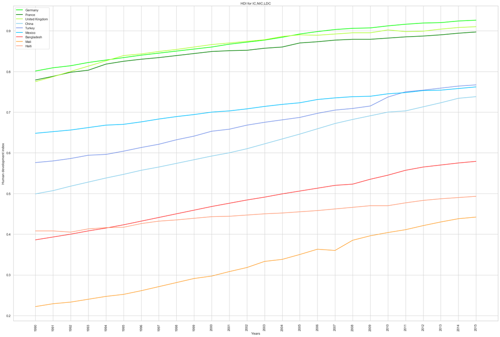

```python
# HDI visualisation


sns.set(style='whitegrid')
fig,ax = plt.subplots(figsize=(30,20))

#column names of all 3 df´s
labels = hdi_ict.index;
labels1 = hdi_nict.index;

hdi_ic_ger =sns.lineplot(data=swapcol(hdi_ic),x=labels,y='Germany',ax=ax,label='Germany',color=c_germany,alpha=1,lw=2);
hdi_ic_fr = sns.lineplot(data=swapcol(hdi_ic),x=labels,y='France',ax=ax,label='France',color=c_france,alpha=1,lw=2);
hdi_ic_uk = sns.lineplot(data=swapcol(hdi_ic),x=labels,y='United Kingdom',ax=ax,label='United Kingdom',color=c_unitedkingdom,alpha=1,lw=2);

hdi_ch =sns.lineplot(data=swapcol(hdi_nic),x=labels1,y='China',ax=ax,label='China',color=c_china,alpha=1,lw=2);
hdi_tu = sns.lineplot(data=swapcol(hdi_nic),x=labels1,y='Turkey',ax=ax,label='Turkey',color=c_turkey,alpha=.7,lw=2);
hdi_mx = sns.lineplot(data=swapcol(hdi_nic),x=labels1,y='Mexico',ax=ax,label='Mexico',color=c_mexico,alpha=1,lw=2);

hdi_ic_ba =sns.lineplot(data=swapcol(hdi_ldc),x=labels,y='Bangladesh',ax=ax,label='Bangladesh',color=c_bangladesh,alpha=1);
hdi_ic_ma = sns.lineplot(data=swapcol(hdi_ldc),x=labels,y='Mali',ax=ax,label='Mali',color=c_mali,alpha=1);
hdi_ic_hai = sns.lineplot(data=swapcol(hdi_ldc),x=labels,y='Haiti',ax=ax,label='Haiti',color=c_haiti,alpha=1);


# rotating years 90 degrees, labels
ax.set_xticklabels(rotation=90,labels=labels)
ax.set_xlabel(xlabel='Years');
ax.set_title('HDI for IC,NIC,LDC')

ax.set_ylabel(ylabel='Human development index')
ax.set_xlabel(xlabel='Years');
```

```
variance index IC,NIC,LDC
[0.00980957191112935]
[0.12372779864500759]
[0.31965660431447146]
```

[figure not shown]

```python
index = list(hdi_proc.index)
hdi_compare =sns.catplot(x=index, y="procent", data=s_proc,height=6, kind="bar", palette=c_palette,size=4, aspect=2)
hdi_compare.set_xticklabels(rotation=90,labels=index)



hdi_compare.set(title='Changing trend in %, HDI ',xlabel='')
print('variance index IC,NIC,LDC')
varg(hdi_list);
```

Although HDI is a very good indicator for grouping IC,NIC,LDC´s, because as we can see, in the lineplot, all of the 3 country categories are visually grouped by their industry definition :)

### GINI inequality

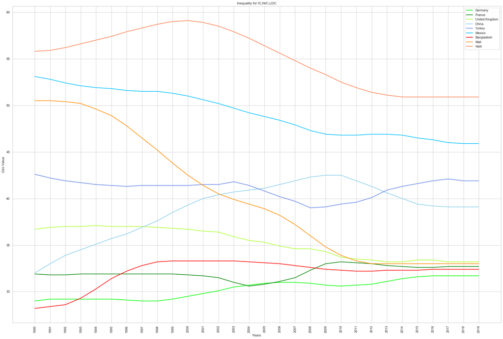

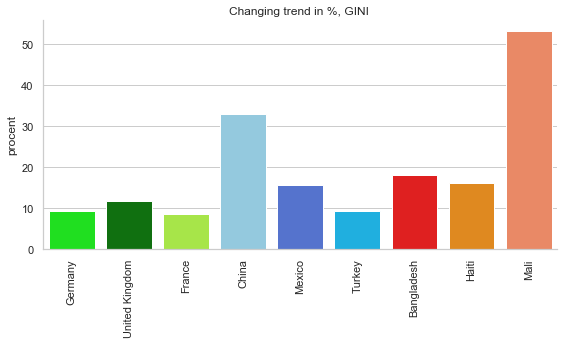

```python
# gini visualisation


sns.set(style='whitegrid')
# exploring GINI - IC,NIC,LDC category
fig,ax = plt.subplots(figsize=(30,20))

#column names of all 3 df´s
labels = gini_ict.index;
labels2 = gini_ldct.index;


gini_ic_ger =sns.lineplot(data=swapcol(gini_ic),x=labels,y='Germany',ax=ax,label='Germany',color=c_germany,alpha=1,lw=2);
gini_ic_fr = sns.lineplot(data=swapcol(gini_ic),x=labels,y='France',ax=ax,label='France',color=c_france,alpha=1,lw=2);
gini_ic_uk = sns.lineplot(data=swapcol(gini_ic),x=labels,y='United Kingdom',ax=ax,label='United Kingdom',color=c_unitedkingdom,alpha=1,lw=2);

gini_nic_ch =sns.lineplot(data=swapcol(gini_nic),x=labels,y='China',ax=ax,label='China',color=c_china,alpha=1,lw=2);
gini_nic_tu = sns.lineplot(data=swapcol(gini_nic),x=labels,y='Turkey',ax=ax,label='Turkey',color=c_turkey,alpha=.8,lw=2);
gini_nic_mx = sns.lineplot(data=swapcol(gini_nic),x=labels,y='Mexico',ax=ax,label='Mexico',color=c_mexico,alpha=1,lw=2);

gini_ic_ba =sns.lineplot(data=swapcol(gini_ldc),x=labels2,y='Bangladesh',ax=ax,label='Bangladesh',color=c_bangladesh,alpha=1,lw=2);
gini_ic_ma = sns.lineplot(data=swapcol(gini_ldc),x=labels2,y='Mali',ax=ax,label='Mali',color=c_mali,alpha=1,lw=2);
gini_ic_ht = sns.lineplot(data=swapcol(gini_ldc),x=labels2,y='Haiti',ax=ax,label='Haiti',color=c_haiti,alpha=1,lw=2);


# rotating years 90 degrees, labels
ax.set_xticklabels(rotation=90,labels=labels)
ax.set_ylabel(ylabel='Gini Value')
ax.set_xlabel(xlabel='Years');
ax.set_title('Inequality for IC,NIC,LDC');


index = list(hdi_proc.index)
hdi_compare =sns.catplot(x=index, y="procent", data=gini_proc,height=6, kind="bar", palette=c_palette,size=4, aspect=2)
hdi_compare.set_xticklabels(rotation=90,labels=index)



hdi_compare.set(title='Changing trend in %, GINI ',xlabel='');
```

```python
print('variance index IC,NIC,LDC')
varg(gini_list);
```

```
variance index IC,NIC,LDC
[0.013809561537731193]
[0.0995031643283084]
[0.1695803664437462]
```

#### Inequality

- "Economists from the group, which is funded by developed-world taxpayers, say the annual average income in the UK of the top 10% in 2008 was just under £55,000, about 12 times higher than that of the bottom 10%, who had an average income of £4,700. This is up from a ratio of eight to one in 1985 and significantly higher than the average income gap in developed nations of nine to one. However, the report makes clear that even in countries viewed as "fairer" – such as Germany, Denmark and Sweden – this pay gap between rich and poor is expanding: from five to one in the 1980s to six to one today. In the rising powers of Brazil, Russia, India and China, the ratio is an alarming 50 to one. The OECD warned about the rise of the top 1% in rich societies and the falling share of income going to poorer people." https://www.theguardian.com/society/2011/dec/05/income-inequality-growing-faster-uk

This is up from a ratio of eight to one in 1985 and significantly higher than the average income gap in developed nations of nine to one.

However, the report makes clear that even in countries viewed as "fairer" – such as Germany, Denmark and Sweden – this pay gap between rich and poor is expanding: from five to one in the 1980s to six to one today. In the rising powers of Brazil, Russia, India and China, the ratio is an alarming 50 to one.

The OECD warned about the rise of the top 1% in rich societies and the falling share of income going to poorer people.

```
 _
```

- "Jump to search Chinese industrialization refers to the process of China undergoing various stages of industrialization with a focus on the period after the establishment of the People's Republic of China where China experienced its most notable growths in industrialization. Although Chinese industrialization is largely defined by its 20th-century campaigns, China has a long history that contextualizes the proto-industrial efforts, and explains the reasons for delay of industrialization in comparison to Western countries. In 1952, 83 percent of the Chinese workforce were employed in agriculture. figure remained high, but was declining steadily, throughout the early phase of industrialization between the 1960s and 1990s, but in view of the rapid population growth this amounted to a rapid growth of the industrial sector in absolute terms, of up to 11 percent per year during the period.[2][3] By 1977, the fraction of the workforce employed in agriculture had fallen to about 77 percent, and by 2012, 33 percent." https://en.wikipedia.org/wiki/Chinese_industrialization

but since then, inequality were growing fast until, end of the financial crisis 2009/2010.

```
_
```

LDC´s : Maili and Haiti have a same trend curve, but bangladesh is rising up in inequality, interesting observation because the used to lower the inequality but within the same time window, as chinese industry revolution begun.

Please note inequality is comparing highest income with lowest income, especially for LDC´s we see low GINI rating which dont mean that the overall state of the countries can be compared with IC´s. For example germany have a average income per person about circa 46.560 dollars, and mali have 1500 dollars, annual.

### Death trends exploration

#### Murdered people in total

Lets compare the murdered people, in total, trends. As we can see mexico and china have higher rates in total, I will exlude them within another lineplot to give a better visual for the IC and LDC´s.

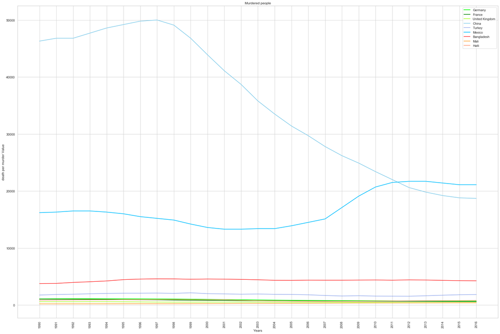

```python
# murder visualisation


sns.set(style='whitegrid')
# exploring death by murder- IC,NIC,LDC category
fig,ax = plt.subplots(figsize=(30,20))

#column names of all 3 df´s
labels = m_ict.index;
labels1 = m_nict.index;

murder_ic_ger =sns.lineplot(data=m_ict,x=labels,y='Germany',ax=ax,label='Germany',color=c_germany,alpha=1,lw=2);
murder_ic_fr = sns.lineplot(data=m_ict,x=labels,y='France',ax=ax,label='France',color=c_france,alpha=1,lw=2);
murder_ic_uk = sns.lineplot(data=m_ict,x=labels,y='United Kingdom',ax=ax,label='United Kingdom',color=c_unitedkingdom,alpha=1,lw=2);

murder_nic_ch =sns.lineplot(data=m_nict,x=labels1,y='China',ax=ax,label='China',color=c_china,alpha=1,lw=2);
murder_nic_tu = sns.lineplot(data=m_nict,x=labels1,y='Turkey',ax=ax,label='Turkey',color=c_turkey,alpha=0.5,lw=2);
murder_nic_mx = sns.lineplot(data=m_nict,x=labels1,y='Mexico',ax=ax,label='Mexico',color=c_mexico,alpha=1,lw=2);

murder_ic_ger =sns.lineplot(data=m_ldct,x=labels,y='Bangladesh',ax=ax,label='Bangladesh',color=c_bangladesh,alpha=1);
murder_ic_fr = sns.lineplot(data=m_ldct,x=labels,y='Mali',ax=ax,label='Mali',color=c_mali,alpha=1);
murder_ic_uk = sns.lineplot(data=m_ldct,x=labels,y='Haiti',ax=ax,label='Haiti',color=c_haiti,alpha=1);


# rotating years 90 degrees, labels
ax.set_xticklabels(rotation=90,labels=labels)
ax.set_ylabel(ylabel='death per murder Value')
ax.set_xlabel(xlabel='Years');
ax.set_title('Murdered people');
```

It turns out, the rising inequality(GINI) rating shows a negative correlation with murder rates, so improving HDI rating helps to bring the trend curve down for IC´s.

But not for Mexico. Where inequality is decreasing and HDI improving. Even in the corona time murder rate in mexico wont drop down. This can be an interesting research reason for a new jupyter notebook.

- "López Obrador came to power promising to solve Mexico’s security woes by tacking what he considered the root causes of crime: poverty and corruption. But the strategy has so far failed to rein in the violence.

  “The [anti-crime] strategy isn’t a strategy,” said Rivas. “The national guard isn’t pulling its weight because building an institution is difficult and expensive. Budget cuts to public security have been brutal. These all have serious effects.” "

  https://www.theguardian.com/world/2020/apr/03/mexico-murder-rate-homicide-coronavirus-covid-19

In the last years the rate still had stabilized which is a positive outcome.

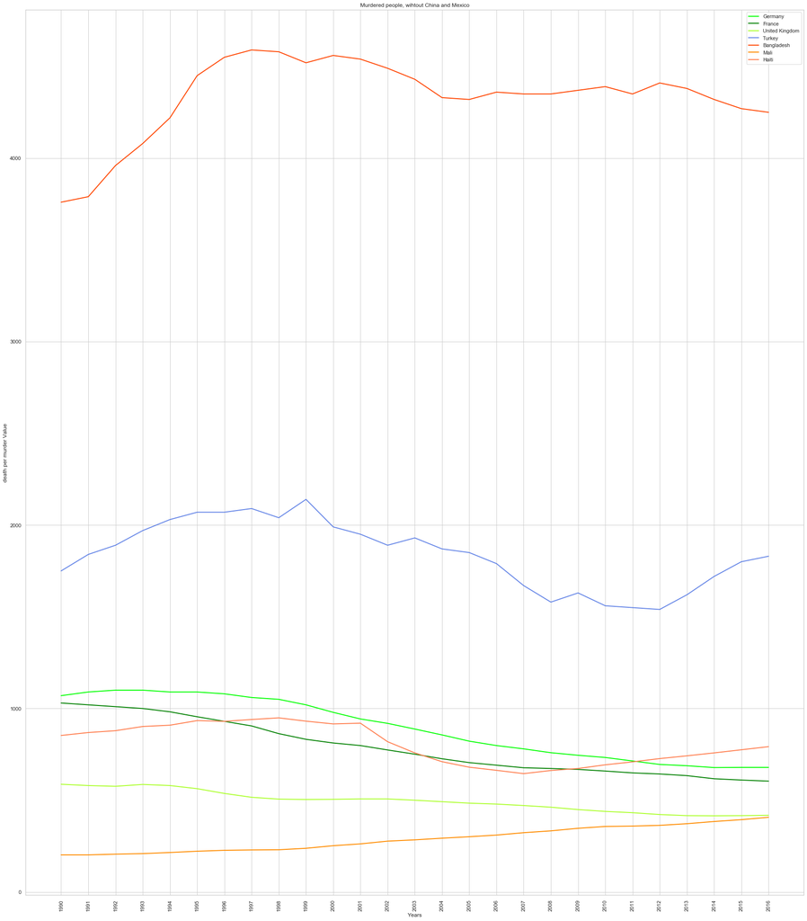

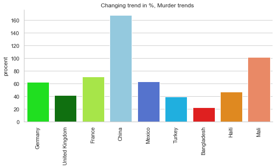

```python
#exclude mexico turkey

# murder visualisation


sns.set(style='whitegrid')
# exploring death by murder- IC,NIC,LDC category
fig,ax = plt.subplots(figsize=(30,35))

#column names of all 3 df´s
labels = m_ict.index;
labels1 = m_nict.index;

murder_ic_ger =sns.lineplot(data=m_ict,x=labels,y='Germany',ax=ax,label='Germany',color=c_germany,alpha=1,lw=2);
murder_ic_fr = sns.lineplot(data=m_ict,x=labels,y='France',ax=ax,label='France',color=c_france,alpha=1,lw=2);
murder_ic_uk = sns.lineplot(data=m_ict,x=labels,y='United Kingdom',ax=ax,label='United Kingdom',color=c_unitedkingdom,alpha=1,lw=2);

#murder_nic_ch =sns.lineplot(data=m_nict,x=labels1,y='China',ax=ax,label='China',color='navy',alpha=0.6,lw=2);
murder_nic_tu = sns.lineplot(data=m_nict,x=labels1,y='Turkey',ax=ax,label='Turkey',color='royalblue',alpha=.8,lw=2);
#murder_nic_mx = sns.lineplot(data=m_nict,x=labels1,y='Mexico',ax=ax,label='Mexico',color='deepskyblue',alpha=2);

murder_ic_ger =sns.lineplot(data=m_ldct,x=labels,y='Bangladesh',ax=ax,label='Bangladesh',color='orangered',alpha=1,lw=2);
murder_ic_fr = sns.lineplot(data=m_ldct,x=labels,y='Mali',ax=ax,label='Mali',color='darkorange',alpha=1,lw=2);
murder_ic_uk = sns.lineplot(data=m_ldct,x=labels,y='Haiti',ax=ax,label='Haiti',color='coral',alpha=1,lw=2);


# rotating years 90 degrees, labels
ax.set_xticklabels(rotation=90,labels=labels)
ax.set_ylabel(ylabel='death per murder Value')
ax.set_xlabel(xlabel='Years');
ax.set_title('Murdered people, wihtout China and Mexico');

#bar ccahrt
index = list(m_proc.index)
m_compare =sns.catplot(x=index, y="procent", data=m_proc,height=6, kind="bar", palette=c_palette,size=4, aspect=2)
m_compare.set_xticklabels(rotation=90,labels=index)



m_compare.set(title='Changing trend in %, Murder trends ',xlabel='')
```

```python
print('variance index IC,NIC,LDC')
varg(m_list);
```

```
variance index IC,NIC,LDC
[0.12234049010686364]
[0.5571655979755139]
[0.3314649896550115]
```

```python
m_proc.max()
```

```
procent    167.379679
dtype: float64
```

IC´s (green colors) have a slightly decrasing murder trends which can be based on generell stabelized GDP and growing GINI and HDI. Overall murder rates are very low but the curve goes for a more even trend in the recent years.

### Suicide rates

Plotting suicide rates for the three country types, on the same way as before.

A hypothesis for higher Rates in China than in the rest of the IC,NIC,LDC´s.

- "Easy access to the means of suicide has been discussed as the most prominent reason why suicide rates are high in China. Pesticide availability is one example. Nearly all rural households store pesticides, which makes suicide means readily available in the Chinese countryside (The Economist, 1997). Handguns, which are a primary means of suicide in the West, are not available to Chinese civilians, and account for only about 0.1% of Chinese suicides (Zhang, 1996). Although usually less violent and less efficient than guns, pesticides can be an efficient means of suicide if they are easily available and if few hospitals are equipped to treat patients who have ingested them. No reliable figures yet exist for the ratio of attempted suicides to completed suicides in China. The difference between China and other countries may lie not so much in a higher rate of attempted suicide, but in a higher rate of attempted suicides that die because of unsuccessful remedial action (The Economist, 1997)."

https://www.ncbi.nlm.nih.gov/pmc/articles/PMC2913725/

But as we can see rates are dropping hard as the "developing state" of the country is evolving even more and more. See HDI

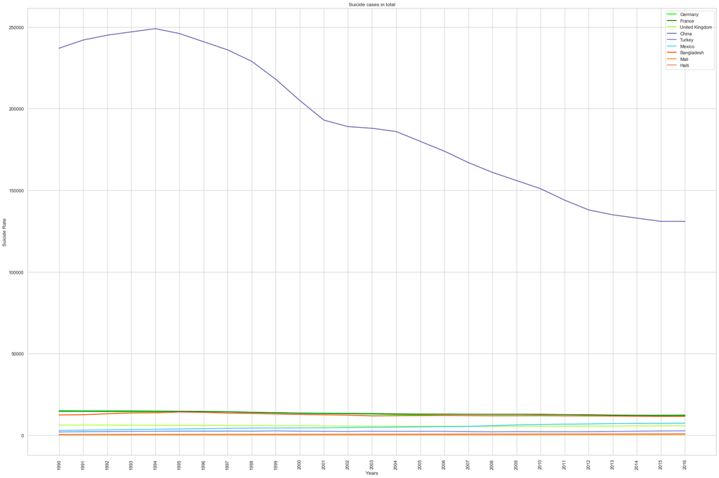

```python
# suicide visualisation china


sns.set(style='whitegrid')
# exploring suicide - IC,NIC,LDC category
fig,ax = plt.subplots(figsize=(30,20))

#column names of all 3 df´s
labels = s_ict.index;
labels1 = s_nict.index;

suicide_ic_ger =sns.lineplot(data=s_ict,x=labels,y='Germany',ax=ax,label='Germany',color=c_germany,alpha=1,lw=2);
suicide_ic_fr = sns.lineplot(data=s_ict,x=labels,y='France',ax=ax,label='France',color=c_france,alpha=1,lw=2);
suicide_ic_uk = sns.lineplot(data=s_ict,x=labels,y='United Kingdom',ax=ax,label='United Kingdom',color=c_unitedkingdom,alpha=1,lw=2);

murder_nic_ch =sns.lineplot(data=s_nict,x=labels1,y='China',ax=ax,label='China',color='navy',alpha=0.6,lw=2);
suicide_nic_tu = sns.lineplot(data=s_nict,x=labels1,y='Turkey',ax=ax,label='Turkey',color='royalblue',alpha=.8,lw=2);
suucide_nic_mx = sns.lineplot(data=s_nict,x=labels1,y='Mexico',ax=ax,label='Mexico',color='deepskyblue',alpha=2);

suicide_ic_ger =sns.lineplot(data=s_ldct,x=labels,y='Bangladesh',ax=ax,label='Bangladesh',color='orangered',alpha=1,lw=2);
suicide_ic_fr = sns.lineplot(data=s_ldct,x=labels,y='Mali',ax=ax,label='Mali',color='darkorange',alpha=1,lw=2);
suicide_ic_uk = sns.lineplot(data=s_ldct,x=labels,y='Haiti',ax=ax,label='Haiti',color='coral',alpha=1,lw=2);


# rotating years 90 degrees, labels
ax.set_xticklabels(rotation=90,labels=labels)
ax.set_ylabel(ylabel='Suicide Rate')
ax.set_xlabel(xlabel='Years');
ax.set_title('Suicide cases in total');
```

[figure not shown]

```python
# suicide visualisation excluding china


sns.set(style='whitegrid')
# exploring suicide - IC,NIC,LDC category
fig,ax = plt.subplots(figsize=(30,30))

#column names of all 3 df´s
labels = s_ict.index;
labels1 = s_nict.index;

suicide_ic_ger =sns.lineplot(data=s_ict,x=labels,y='Germany',ax=ax,label='Germany',color=c_germany,alpha=1,lw=2);
suicide_ic_fr = sns.lineplot(data=s_ict,x=labels,y='France',ax=ax,label='France',color=c_france,alpha=1,lw=2);
suicide_ic_uk = sns.lineplot(data=s_ict,x=labels,y='United Kingdom',ax=ax,label='United Kingdom',color=c_unitedkingdom,alpha=1,lw=2);

#suicide_nic_ch =sns.lineplot(data=s_nict,x=labels1,y='China',ax=ax,label='China',color='navy',alpha=0.6,lw=2);
suicide_nic_tu = sns.lineplot(data=s_nict,x=labels1,y='Turkey',ax=ax,label='Turkey',color='royalblue',alpha=.8,lw=2);
suicide_nic_mx = sns.lineplot(data=s_nict,x=labels1,y='Mexico',ax=ax,label='Mexico',color='deepskyblue',alpha=2);

suicide_ic_ger =sns.lineplot(data=s_ldct,x=labels,y='Bangladesh',ax=ax,label='Bangladesh',color='orangered',alpha=1,lw=2);
suicide_ic_fr = sns.lineplot(data=s_ldct,x=labels,y='Mali',ax=ax,label='Mali',color='darkorange',alpha=1,lw=2);
suicide_ic_uk = sns.lineplot(data=s_ldct,x=labels,y='Haiti',ax=ax,label='Haiti',color='coral',alpha=1,lw=2);


# rotating years 90 degrees, labels
ax.set_xticklabels(rotation=90,labels=labels)
ax.set_ylabel(ylabel='Suicide Rate')
ax.set_xlabel(xlabel='Years');
ax.set_title('Suicide cases in total');
```

```
biggest change: procent    149.66443
dtype: float64
Variance IC,NIC,LDC
[0.03711641966096393]
[0.47951662357395924]
[0.22520870047014888]
```

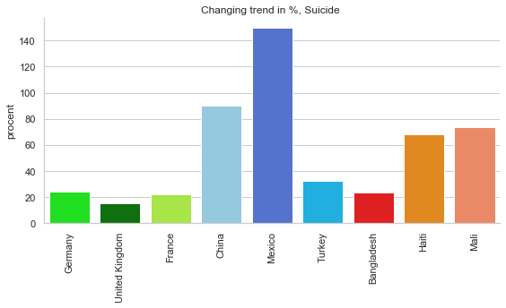

```python
slist = [s_ic,s_nic,s_ldc]
index = list(s_proc.index)
s_compare =sns.catplot(x=index, y="procent", data=s_proc,height=6, kind="bar", palette=c_palette,size=4, aspect=2)
s_compare.set_xticklabels(rotation=90,labels=index)



s_compare.set(title='Changing trend in %, Suicide ',xlabel='')

print('biggest change: ' + str(s_proc.max()))

s_proc.loc['Haiti']
print('Variance IC,NIC,LDC')
varg(slist)
```

Mexico have an increasing suicide rate with a 149% rate.

- "Robert Burton presciently implicated the quality and quantity of diet, heredity, solitude, idleness, sleep, loss/sorrow, fear, shame, envy, malice, ambition, vanity, excessive study[!], and poverty as causes of melancholy over 350 years ago (Burton, 1845). There has been much progress, but countless questions circling the concept of depression and its origins still remain unanswered. A better understanding of large-scale causes and the complex relationships between modern culture, chronic disease, and depression will be essential for systemic, population-based interventions to address a very common affliction. More research is necessary to unravel the role of specific health behaviors within individual depressive phenotypes, e.g. atypical versus melancholic depression." https://www.ncbi.nlm.nih.gov/pmc/articles/PMC3330161/

LDC´s : For least developed countries we see a negative trend for Bangladesh with a flattening curve in 2015.

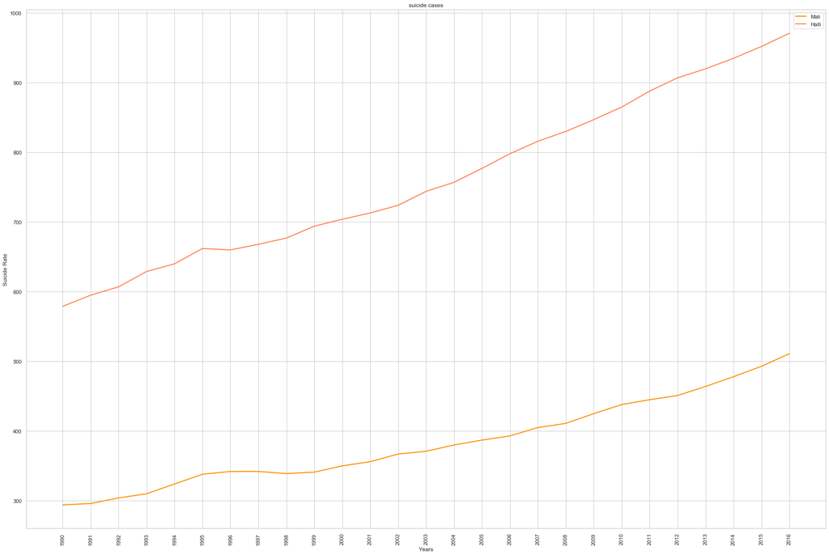

```python
# suicide visualisation mali haiti


sns.set(style='whitegrid')
# exploring suicide - IC,NIC,LDC category
fig,ax = plt.subplots(figsize=(30,20))

#column names of all 3 df´s
labels = s_ict.index;
labels1 = s_nict.index;

suicide_ic_fr = sns.lineplot(data=s_ldct,x=labels,y='Mali',ax=ax,label='Mali',color='darkorange',alpha=1,lw=2);
suicide_ic_uk = sns.lineplot(data=s_ldct,x=labels,y='Haiti',ax=ax,label='Haiti',color='coral',alpha=1,lw=2);


# rotating years 90 degrees, labels
ax.set_xticklabels(rotation=90,labels=labels)
ax.set_ylabel(ylabel='Suicide Rate')
ax.set_xlabel(xlabel='Years');
ax.set_title('suicide cases');
```

```python
prop_minmax(gini_all)
```

| country | Germany | United Kingdom | France | China | Mexico | Turkey | Bangladesh | Haiti | Mali |
| --- | --- | --- | --- | --- | --- | --- | --- | --- | --- |
| min | 29.000000 | 33.200000 | 30.600000 | 32.0000 | 45.900000 | 39.000000 | 28.200000 | 50.90000 | 33.000000 |
| max | 31.700000 | 37.100000 | 33.200000 | 42.5000 | 53.100000 | 42.600000 | 33.300000 | 59.10000 | 50.500000 |
| difference | 2.700000 | 3.900000 | 2.600000 | 10.5000 | 7.200000 | 3.600000 | 5.100000 | 8.20000 | 17.500000 |
| procent | 9.310345 | 11.746988 | 8.496732 | 32.8125 | 15.686275 | 9.230769 | 18.085106 | 16.11002 | 53.030303 |

## 4. Conclusions

Newly industrialized countries : They tend to have a great variance between all indicators and death reasons. China stands out because we can see big movements in trends.

CHINA:

As conclusion we can say that the HDI and GINI did affect most of NIC´s. The great variance in every indicator gives a great view of the definition of a NIC´s; that those countries are changing with the factors a newly industrialized country have.

Industrialized countries : There is a major trend in all % changes in this country category. As we can see in the barplots, IC´s always have very low variance in their changes even if the % change is between 40% in some cases, between the IC´s eachother, they stay close in the change rate, compared with the rest of the change rates.

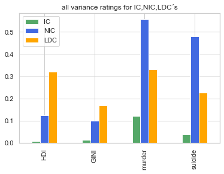

```python
# quick plot for variance % change in key indicators and death reasons
colu = ['IC','NIC','LDC']
index = ['HDI','GINI','murder','suicide']
dfa = np.array([[0.0098,0.1237,0.3196],[0.0138,0.0995,0.1695,],[0.1223,0.5571,0.3314],[0.0371,0.4795,0.2252]])
varg_all = pd.DataFrame(dfa,columns=colu,index=index)

varg_all.plot(kind='bar',color=['g','royalblue','orange'],title='all variance ratings for IC,NIC,LDC´s')
```

It is really good to see that all 3 country categories are changing as their category type defines it. Usually you will make some assumptions about countries because you maybe heard something from some one other or from some news reports. But in this notebook you can slightly see that all those statements about poor countries or industry nations are kind of defined by a statistic base.

```python
"Le fin"
```